# Working with Markdown

Rachel Hall

2024-01-23

For markdown, use asterisks to *indicate italic text*.

Double line return for a new chunk of text like this.

Name  
Department of Biology  
University of Vermont

# Hash marks for headers

## more hashes for progressively

### smaller

#### headers

**bold face this way**

> Offset quote which embeds for extended material that you would like to see.

Back to plain text

- first list item
- second item
  - spacing for indents
  - <sup>superscript</sup> but also a <sub>subscript</sub> like this

set up a link with text

also footnotes[^1]

| First Header | Second Header |
| --- | --- |
| Content Cell | Content Cell |
| Content Cell | Content Cell |

```
Fencing sets boundaries and everything inside the fencing *is shown as literal text* without rendering
```

$$a + b =c$$
We can also use Latex in line with a single dollar sign $a+b=c$ like this.

### Subscripts in LaTex

$$H_0 = Z_{a + b}$$
$$S=cA^z_1 + z_{2 + x}$$

$$\alpha = \frac{\beta}{\delta +
\gamma_x}$$

$$z = \sum_{i=1}^X{K}$$

### “Escaping” the special character in LaTeX

Dollar sign distinguishes LaTex math expression from regular text. Backslash is used to generate a special symbol or command.

Use backslash
$$\backslash$$
$$\backslash \alpha \le b \backslash$$

### Rendering in plain text

$$P(Occurrence Of Species A) =
Z$$

$$P(\mbox{Occurrence Of Species A}) =
Z$$

### Embedding

Easy to embed LaTex in line $\pi + 3$ like so. We can also use markdown fencing in line with a single backtick `pi + 3` like this. We can even execute r code inside of markdown text 6.1415927

### Running R Code

R chunk is created using three backticks and { r }

Eval is whether or not to evaluate the code and include its results.

Echo determines if the code if displayed with the results of the code (false = doesn’t show).

```r
# Use comments extensively in ALL of your coding!
Pred <- seq(1,10)     # make a vector of integers from 1 to 10
Res <- runif(10)      # generate 10 draws from a random uniform (0,1) distribution

# print the random numbers
print(Res)
```

```
##  [1] 0.38777138 0.95553006 0.64457719 0.09768174 0.29281263 0.83130102
##  [7] 0.05660561 0.01524271 0.70991470 0.65043840
```

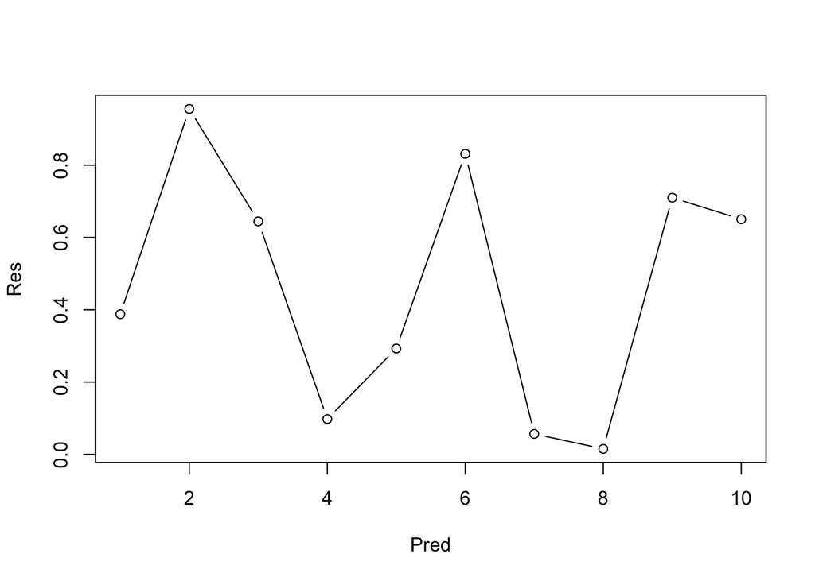

```r
# plot the graph
plot(x=Pred,y=Res,type="b")
```

[^1]: at bottom of page